# Create County Population File

Author

Aaron R. Williams

Published

September 22, 2026

Abstract

This script pulls US Census Bureau Population Estimation Program and Decennial Census data to create a list of counties with population estimates for 2014-2024

```r
library(tidyverse)
library(tidycensus)
library(assertr)
library(here)

theme_set(theme_minimal())
options(scipen = 999)
```

```r
number_of_years <- 12
```

## 2014

In 2014, there are 3,142 counties. In 2020, Valdez-Cordova Census Area split into Chugach Census Area and Copper River Census Area.

```r
#' Get population estimates from the US Census Bureau Population Estimation Program manually for 2014
#'
#' @param year An integer for the year of interest
#'
#' @return A data frame with estimate for all US counties
#'
## 2014

# Specify URL where source data file is online
# FYI for variable information: https://www.census.gov/data/developers/data-sets/popest-popproj/popest/popest-vars/2019.html
countyurl14 <-
  "https://www2.census.gov/programs-surveys/popest/datasets/2010-2014/counties/totals/co-est2014-alldata.csv"

# Specify destination where file should be saved (the .gitignore folder for your local branch)
destfilecounty14 <- here("geographic-crosswalks", "data", "raw", "co-est2014.csv")

# Import the data file & save locally
if (!file.exists(destfilecounty14)) {
  download.file(countyurl14, destfilecounty14, mode = "wb")
}

# the 2014 file is Latin-1 encoded (later vintages are UTF-8); without this,
# Doña Ana County, NM fails to split into state_name and county_name
pep_2014 <- read_csv(destfilecounty14, locale = locale(encoding = "latin1")) %>%
  rename_with(tolower) %>%
  # Convert state to character and add a leading zero
  mutate(
    state = str_pad(state, width = 2, pad = "0"),
    place = str_pad(county, width = 3, pad = "0"),
    GEOID = paste0(state, place)
  ) %>%
  # remove unnecessary data first
  filter(county != "000") %>%
  mutate(across(c(state, county), as.character)) %>%
  filter(sumlev == "050") %>%
  mutate(variable = "POP") %>%
  mutate(NAME = paste0(stname, ", ", ctyname),
         ) %>%
  select(
    GEOID, NAME, variable,
    starts_with("popestimate")
  ) %>%
  # reshape by place
  pivot_longer(
    cols = starts_with("popestimate"),
    names_to = "year",
    values_to = "value"
  ) %>%
  mutate(
    year = as.numeric(str_remove(string = year, pattern = "popestimate")),
  ) %>%
  filter(year > 2013)
```

## 2015-2019

In 2015-2019, there are 3,142 counties. In 2020, Valdez-Cordova Census Area split into Chugach Census Area and Copper River Census Area.

```r
#' Get population estimates from the US Census Bureau Population Estimation Program
#'
#' @param year An integer for the year of interest
#'
#' @return A data frame with estimate for all US counties
#'
get_pop <- function(year) {

  pop <- get_estimates("county", year = year, variables = "POP") |>
    mutate(year = year)

  return(pop)

}


# pull county population data for each year from the Population Estimates Program
pep_2015_2019 <- map_dfr(
  .x = 2015:2019,
  .f = ~get_pop(year = .x)
)
```

## 2020

```r
# pull the 2020 decennial census
census2020 <- get_decennial(geography = "county", year = 2020, variables = "P1_001N") |>
  select(NAME, GEOID, variable, value) |>
  mutate(year = 2020)

# combine the PEP data and decennial census data
pop <- bind_rows(pep_2014, pep_2015_2019, census2020)


# split GEOID into state and county
pop <- pop %>%
  mutate(state = str_sub(GEOID, start = 1, end = 2),
         county = str_sub(GEOID, start = 3, end = 5)) %>%
  select(-GEOID)

# drop PR
pop <- pop |>
  filter(state != "72")

# separate out 2014 and the remaining years to make county and state name variables

pop_14 <- pop |>
  filter(year == 2014) |>
  separate(NAME, into = c("state_name", "county_name", "c", "d", "e"), sep = ",") |>
  mutate(state_name = str_trim(state_name)) |>
  select(-c, -d, -e)

pop <- pop |>
  filter(year != 2014) |>
  separate(NAME, into = c("county_name", "state_name", "c", "d", "e"), sep = ",") |>
  mutate(state_name = str_trim(state_name)) |>
  select(-c, -d, -e) |>
  bind_rows(pop_14)

# drop unnecessary variable and rename the useful variable
pop <- pop %>%
  mutate (population = value) %>%
  select(state, county, state_name, county_name, year, population)


# clean one messy county name from New Mexico
pop <- pop |>
  select(year, state, county, state_name, county_name, population) |>
  arrange(year, state, county) |>
  mutate(county_name = if_else(county_name == "DoÃ±a Ana County", "Doña Ana County", county_name))
```

## 2021-2024

The [Population Estimates Program](https://www.census.gov/data/datasets/time-series/demo/popest/2020s-counties-total.html) data isn’t available through the Census Bureau API for later year. Instead, we download and clean up the data.

```r
read_pep <- function(year) {

  file <- here("geographic-crosswalks", "data", "raw", paste0("pep", year, ".csv"))

  url <-
    paste0("https://www2.census.gov/programs-surveys/popest/datasets/",
           "2020-", year, "/counties/totals/co-est", year, "-alldata.csv")

  if (!file.exists(file)) {

    download.file(
      url = url,
      destfile = file
    )


  }

  pop_var <- paste0("popestimate", year)

  pep <- read_csv(file) |>
    rename_with(tolower) |>
    filter(sumlev == "050") |>
    mutate(year = year) |>
    select(year, state, county, population = any_of(pop_var), any_of(c("stname", "ctyname")))

  return(pep)

}

pep_2021_2024 <- map_dfr(
  .x = 2021:2024,
  .f = read_pep
)

pep_2021_2024 <- pep_2021_2024 |>
  rename(state_name = stname, county_name = ctyname) |>
  mutate(county_name = if_else(str_detect(county_name, "a Ana County"), "Doña Ana County",
                                       county_name))
```

## Combine Data Again

```r
final_population <- bind_rows(
  pop,
  pep_2021_2024
)

final_population <- final_population |>
  arrange(year, state, county) |>
  mutate(in_universe = TRUE)
```

Fix a typo in the county name for “Lower Connecticut River Valley Planning Region”

```r
final_population <- final_population |>
  mutate(county_name = if_else(state == "09" & county == "130",
    "Lower Connecticut River Valley Planning Region", county_name
  ))
```

SOme county names have excess white spaces.

```r
final_population <- final_population |>
  mutate(county_name = str_trim(county_name))
```

## Add 2025 Data

We need counties for 2025 but skip adding the population, which isn’t available yet.

```r
final_population <- bind_rows(
  final_population,
  final_population |>
    filter(year == 2024) |>
    mutate(year = 2025) |>
    select(-population)
)
```

## Evaluate

```r
get_n_counties <- function(data, filtering_expression) {
  n_counties <-
    filter(data, {{ filtering_expression }}) |>
    count(year) |>
    pull(n) |>
    unique()

  return(n_counties)
}

n_counties_2014_2019 <- get_n_counties(final_population, year <= 2019)
n_counties_2020_2021 <- get_n_counties(final_population, between(year, 2020, 2021))
n_counties_2022_2023 <- get_n_counties(final_population, year >= 2022)
```

## Evaluation

**Check:** Do we have the expected number of counties?

```r
final_population |>
  count(year) |>
  assert(
    within_bounds(3142, 3144),
    n
  )
```

```
# A tibble: 12 × 2
    year     n
   <dbl> <int>
 1  2014  3142
 2  2015  3142
 3  2016  3142
 4  2017  3142
 5  2018  3142
 6  2019  3142
 7  2020  3143
 8  2021  3143
 9  2022  3144
10  2023  3144
11  2024  3144
12  2025  3144
```

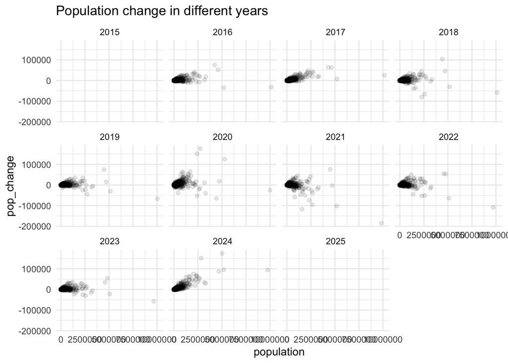

```r
population_test <- final_population |>
  filter(year > 2014) |>
  group_by(state, county) |>
  mutate(
    pop_change = population - lag(population),
    prop_pop_change = (population - lag(population)) / lag(population)
  ) |>
  ungroup()

population_test |>
  ggplot(aes(population, pop_change)) +
  geom_point(alpha = 0.1) +
  facet_wrap(~ year) +
  labs(title = "Population change in different years")
```

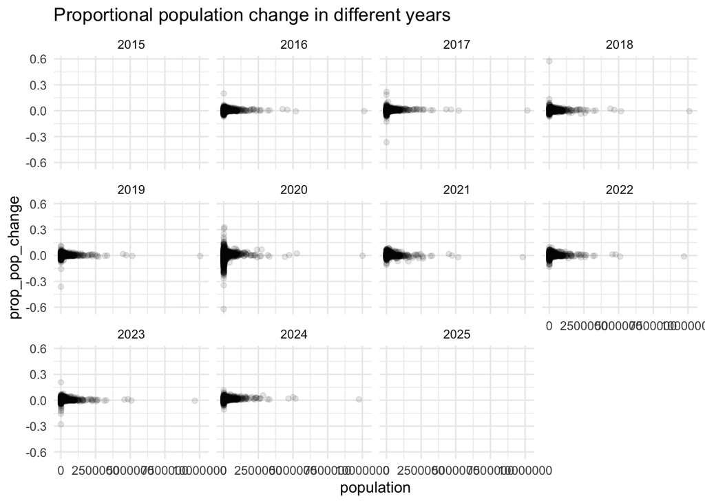

```r
population_test |>
  ggplot(aes(population, prop_pop_change)) +
  geom_point(alpha = 0.1) +
  facet_wrap(~ year) +
  labs(title = "Proportional population change in different years")
```

We can look at the counties with the largest proportion change.

```r
population_test |>
  slice_max(abs(prop_pop_change), n = 30) |>
  print(n = Inf)
```

```
# A tibble: 30 × 9
    year state county state_name   county_name population in_universe pop_change
   <dbl> <chr> <chr>  <chr>        <chr>            <dbl> <lgl>            <dbl>
 1  2020 48    301    Texas        Loving Cou…         64 TRUE              -105
 2  2018 48    095    Texas        Concho Cou…       4276 TRUE              1559
 3  2017 48    095    Texas        Concho Cou…       2717 TRUE             -1562
 4  2019 48    095    Texas        Concho Cou…       2726 TRUE             -1550
 5  2020 48    229    Texas        Hudspeth C…       3202 TRUE             -1684
 6  2020 16    065    Idaho        Madison Co…      52913 TRUE             13006
 7  2020 06    105    California   Trinity Co…      16112 TRUE              3827
 8  2023 48    169    Texas        Garza Coun…       4517 TRUE             -1745
 9  2020 48    137    Texas        Edwards Co…       1422 TRUE              -510
10  2020 25    019    Massachuset… Nantucket …      14255 TRUE              2856
11  2020 13    191    Georgia      McIntosh C…      10975 TRUE             -3403
12  2020 02    068    Alaska       Denali Bor…       1619 TRUE              -478
```

[output cut: 19 more lines]

We can look at counties with the largest absolute change in population.

```r
population_test |>
  slice_max(abs(pop_change), n = 30) |>
  print(n = Inf)
```

```
# A tibble: 30 × 9
    year state county state_name county_name   population in_universe pop_change
   <dbl> <chr> <chr>  <chr>      <chr>              <dbl> <lgl>            <dbl>
 1  2021 06    037    California Los Angeles …    9829544 TRUE           -184465
 2  2020 36    047    New York   Kings County     2736074 TRUE            176171
 3  2024 48    201    Texas      Harris County    5009302 TRUE            174177
 4  2020 36    081    New York   Queens County    2405464 TRUE            151606
 5  2024 12    086    Florida    Miami-Dade C…    2838461 TRUE            151594
 6  2020 17    031    Illinois   Cook County      5275541 TRUE            125308
 7  2021 36    061    New York   New York Cou…    1576876 TRUE           -117375
 8  2022 06    037    California Los Angeles …    9721138 TRUE           -108406
 9  2018 04    013    Arizona    Maricopa Cou…    4410824 TRUE            103791
10  2021 17    031    Illinois   Cook County      5173146 TRUE           -102395
11  2024 17    031    Illinois   Cook County      5182617 TRUE             95545
12  2021 36    047    New York   Kings County     2641052 TRUE            -95022
```

[output cut: 19 more lines]

We can look at counties with FIPS that don’t show up in every year.

```r
final_population |>
  group_by(state, county) |>
  mutate(fips_frequency = n()) |>
  filter(fips_frequency != number_of_years) |>
  ungroup() |>
  distinct(state, county, state_name, county_name) |>
  print(n = Inf)
```

```
# A tibble: 24 × 4
   state county state_name   county_name
   <chr> <chr>  <chr>        <chr>
 1 02    261    Alaska       Valdez-Cordova Census Area
 2 02    270    Alaska       Wade Hampton Census Area
 3 09    001    Connecticut  Fairfield County
 4 09    003    Connecticut  Hartford County
 5 09    005    Connecticut  Litchfield County
 6 09    007    Connecticut  Middlesex County
 7 09    009    Connecticut  New Haven County
 8 09    011    Connecticut  New London County
 9 09    013    Connecticut  Tolland County
10 09    015    Connecticut  Windham County
11 46    113    South Dakota Shannon County
12 02    158    Alaska       Kusilvak Census Area
13 46    102    South Dakota Oglala Lakota County
14 02    063    Alaska       Chugach Census Area
15 02    066    Alaska       Copper River Census Area
16 09    110    Connecticut  Capitol Planning Region
17 09    120    Connecticut  Greater Bridgeport Planning Region
18 09    130    Connecticut  Lower Connecticut River Valley Planning Region
19 09    140    Connecticut  Naugatuck Valley Planning Region
20 09    150    Connecticut  Northeastern Connecticut Planning Region
21 09    160    Connecticut  Northwest Hills Planning Region
22 09    170    Connecticut  South Central Connecticut Planning Region
23 09    180    Connecticut  Southeastern Connecticut Planning Region
24 09    190    Connecticut  Western Connecticut Planning Region
```

We can look at places with county names that don’t show up in every year.

```r
final_population |>
  group_by(state_name, county_name) |>
  mutate(fips_frequency = n()) |>
  filter(fips_frequency != number_of_years) |>
  ungroup() |>
  distinct(state, county, state_name, county_name) |>
  print(n = Inf)
```

```
# A tibble: 24 × 4
   state county state_name   county_name
   <chr> <chr>  <chr>        <chr>
 1 02    261    Alaska       Valdez-Cordova Census Area
 2 02    270    Alaska       Wade Hampton Census Area
 3 09    001    Connecticut  Fairfield County
 4 09    003    Connecticut  Hartford County
 5 09    005    Connecticut  Litchfield County
 6 09    007    Connecticut  Middlesex County
 7 09    009    Connecticut  New Haven County
 8 09    011    Connecticut  New London County
 9 09    013    Connecticut  Tolland County
10 09    015    Connecticut  Windham County
11 46    113    South Dakota Shannon County
12 02    158    Alaska       Kusilvak Census Area
13 46    102    South Dakota Oglala Lakota County
14 02    063    Alaska       Chugach Census Area
15 02    066    Alaska       Copper River Census Area
16 09    110    Connecticut  Capitol Planning Region
17 09    120    Connecticut  Greater Bridgeport Planning Region
18 09    130    Connecticut  Lower Connecticut River Valley Planning Region
19 09    140    Connecticut  Naugatuck Valley Planning Region
20 09    150    Connecticut  Northeastern Connecticut Planning Region
21 09    160    Connecticut  Northwest Hills Planning Region
22 09    170    Connecticut  South Central Connecticut Planning Region
23 09    180    Connecticut  Southeastern Connecticut Planning Region
24 09    190    Connecticut  Western Connecticut Planning Region
```

**Check:** Are county and state names complete and well-formed? A Latin-1 encoded source file (e.g., the 2014 PEP file) can cause `separate()` to fail silently, leaving the full “State, County” string in `state_name` and NA in `county_name`.

```r
final_population |>
  assert(not_na, state_name, county_name) |>
  assert(validUTF8, state_name, county_name) |>
  verify(!str_detect(state_name, ","))
```

```
# A tibble: 37,714 × 7
    year state county state_name county_name     population in_universe
   <dbl> <chr> <chr>  <chr>      <chr>                <dbl> <lgl>
 1  2014 01    001    Alabama    Autauga County       55395 TRUE
 2  2014 01    003    Alabama    Baldwin County      200111 TRUE
 3  2014 01    005    Alabama    Barbour County       26887 TRUE
 4  2014 01    007    Alabama    Bibb County          22506 TRUE
 5  2014 01    009    Alabama    Blount County        57719 TRUE
 6  2014 01    011    Alabama    Bullock County       10764 TRUE
 7  2014 01    013    Alabama    Butler County        20296 TRUE
 8  2014 01    015    Alabama    Calhoun County      115916 TRUE
 9  2014 01    017    Alabama    Chambers County      34076 TRUE
10  2014 01    019    Alabama    Cherokee County      26037 TRUE
# ℹ 37,704 more rows
```

```r
final_population |>
  filter(state == "35", county == "013")
```

```
# A tibble: 12 × 7
    year state county state_name county_name     population in_universe
   <dbl> <chr> <chr>  <chr>      <chr>                <dbl> <lgl>
 1  2014 35    013    New Mexico Doña Ana County     213676 TRUE
 2  2015 35    013    New Mexico Doña Ana County     214295 TRUE
 3  2016 35    013    New Mexico Doña Ana County     214207 TRUE
 4  2017 35    013    New Mexico Doña Ana County     215579 TRUE
 5  2018 35    013    New Mexico Doña Ana County     217522 TRUE
 6  2019 35    013    New Mexico Doña Ana County     218195 TRUE
 7  2020 35    013    New Mexico Doña Ana County     219561 TRUE
 8  2021 35    013    New Mexico Doña Ana County     221508 TRUE
 9  2022 35    013    New Mexico Doña Ana County     223337 TRUE
10  2023 35    013    New Mexico Doña Ana County     225210 TRUE
11  2024 35    013    New Mexico Doña Ana County     229366 TRUE
12  2025 35    013    New Mexico Doña Ana County         NA TRUE
```

## Save Data

The PEP data are reported using the geographies at the time the estimates were generated. This means the 2023 data include Connecticut’s planning regions in 2021 even though they didn’t exist at that point.

```r
write_csv(final_population, here("geographic-crosswalks", "data", "county-populations.csv"))
```